# Team 2 Final Project - Bike Sharing

Renee Aziz & Lydia Zheng

2024-01-31

## Analytic Problem Statement

### Addressing low registered users

Reading the .csv files from Capital Bikeshare, a bikesharing company in Washington D.C., there is an apparent discrepancy between casual users, users that use the service minimally, and registered users, users that have an account with Capital Bikeshare. As business analytics majors, analyzing business conditions is our passion. We would like to tackle the question of how to turn more of these casual users into registered users through targeted marketing.

Capital Bikeshare’s data set[^1] has different variables relating to time and weather. We will not aim to establish which variables cause an increase or decrease in users, but we can hypothesize correlations between variables and changes in the number of registered users. This information can be shared with Capital Bikeshare to experiment with marketing times or perform further research to hypothesize times with proportionally low registered users, but relatively high casual users.

### How we will explore why there are low registered users

We plan to identify days where the number of registered users significantly decreases relative to casual users by evaluating the day.csv data set, which includes information on the description of the day, such as the season, whether it is a working day or a holiday, and the weather; and the number of casual users, registered members, and the total amount of bike share users on a given day. **By pinpointing these patterns, bike share companies can develop targeted marketing strategies to increase registered user engagement and retention.**

In addition, we will be using the Readme.txt data dictionary to understand the data from day.csv. We decided to omit hour.csv from our analysis since we think that the hourly data will be too specific for a marketing plan. It is better to analyze trends on a macro level than on a micro level by hour to generate feasible months or weeks to advertise, not hours. We think that overall trends and correlations on a seasonal basis that change daily is much more indicative of a better marketing plan.

After importing and analyzing our data set and the data dictionary, we will employ the following methodology:

- **Data Importation and Preparation:**
  - Import the day.csv data set and read the Readme.txt data dictionary to understand the purpose of the study, and the meanings of the column names.
  - Remove columns we think aren’t useful for our analysis and create identifiable, consistent, and column names in proper syntax.
  - Identify and fix any missing value(s), duplicates, and/or inconsistencies in the data set.
- **Data Exploration:**
  - Visualize key findings using statistical summaries.
  - Experiment with potential patterns and relationships within the data set through summary statistics and graphing.
  - Identify key influences on the number of casual users and registered members, such as the season, whether it is a working day or a holiday, and the weather. We will also discuss possible correlations but acknowledge our shortcomings in analysis.
- **Data Evaluation:**
  - Evaluate patterns and relationships concisely and efficiently that is easy to understand.
  - Recognize limitations: Essential influences on registered users may be omitted from this data set, and we will delve into why we aren’t proving causation or correlation.

### How the results will help bikeshare companies - the consumer of this report

We anticipate the consumer of our analysis to be other bike share companies so that they can perform a similar analysis on their own data. We anticipate that correlations we find between the time and the weather might apply to other demographics as well despite differences in location and culture. These results will help identify possible correlations between the time, weather, and the number of registered users, and this is exactly what these companies need for their marketing campaigns.

## Required Packages

Import the tidyverse package to help with cleaning up and preparing our data set for analysis through filtering. Most of our work will include filtering the data to prepare it, and tidyverse makes this process more efficient, for example, when we use the mutate function under “Importing the data.”

The dplyr package will be essential for data manipulation. Some functions that we will be using from the package will include the filter(), select(), and the groupby() function. In addition, we will be using the pipe operator (%>%) to make our code more concise.

Lastly, also import the ggplot2 package for the general visualizations, such as the line plot and violin plot.

```r
library(tidyverse) # creating tidy data
library(dplyr)     # transforming data
library(ggplot2)   # visualizing data
```

## Data Preparation and Manipulation

### Data Understanding

Capital Bikeshare in Washington D.C., USA, incorporated the bike share data set to monitor and predict the amount of bike rental counts hourly and daily based on the environmental and seasonal factors. They collected the information every day from 2011 to 2012 while users rented the bikes for use.

### Data Import and Cleaning

We are downloading the day.csv data set and placing it into the data folder. We will then run the following code to import day.csv to the variable ‘bike_share’ and view the first 10 rows in the data set for familiarity. We are also going to use the str() function to become familiar with the data types of the variables and the type of variables available. In addition, we used the is.na() function in colSums() to check if there are any missing values in the data set.

```r
## Usually, if given the link to the file, we would link the file in the
## read.csv function. Since this data is from Kaggle, we downloaded it into a
## folder called "data". We are importing the data here:
bike_share <- read_csv("./data/day.csv")
head(bike_share, 10)
```

```
## # A tibble: 10 × 16
##    instant dteday     season    yr  mnth holiday weekday workingday weathersit
##      <dbl> <date>      <dbl> <dbl> <dbl>   <dbl>   <dbl>      <dbl>      <dbl>
##  1       1 2011-01-01      1     0     1       0       6          0          2
##  2       2 2011-01-02      1     0     1       0       0          0          2
##  3       3 2011-01-03      1     0     1       0       1          1          1
##  4       4 2011-01-04      1     0     1       0       2          1          1
##  5       5 2011-01-05      1     0     1       0       3          1          1
##  6       6 2011-01-06      1     0     1       0       4          1          1
##  7       7 2011-01-07      1     0     1       0       5          1          2
##  8       8 2011-01-08      1     0     1       0       6          0          2
##  9       9 2011-01-09      1     0     1       0       0          0          1
## 10      10 2011-01-10      1     0     1       0       1          1          1
## # ℹ 7 more variables: temp <dbl>, atemp <dbl>, hum <dbl>, windspeed <dbl>,
## #   casual <dbl>, registered <dbl>, cnt <dbl>
```

```r
## Here, we use str() to become more familiar with the data set.
str(bike_share)
```

```
## spc_tbl_ [731 × 16] (S3: spec_tbl_df/tbl_df/tbl/data.frame)
##  $ instant   : num [1:731] 1 2 3 4 5 6 7 8 9 10 ...
##  $ dteday    : Date[1:731], format: "2011-01-01" "2011-01-02" ...
##  $ season    : num [1:731] 1 1 1 1 1 1 1 1 1 1 ...
##  $ yr        : num [1:731] 0 0 0 0 0 0 0 0 0 0 ...
##  $ mnth      : num [1:731] 1 1 1 1 1 1 1 1 1 1 ...
##  $ holiday   : num [1:731] 0 0 0 0 0 0 0 0 0 0 ...
##  $ weekday   : num [1:731] 6 0 1 2 3 4 5 6 0 1 ...
##  $ workingday: num [1:731] 0 0 1 1 1 1 1 0 0 1 ...
##  $ weathersit: num [1:731] 2 2 1 1 1 1 2 2 1 1 ...
##  $ temp      : num [1:731] 0.344 0.363 0.196 0.2 0.227 ...
##  $ atemp     : num [1:731] 0.364 0.354 0.189 0.212 0.229 ...
##  $ hum       : num [1:731] 0.806 0.696 0.437 0.59 0.437 ...
##  $ windspeed : num [1:731] 0.16 0.249 0.248 0.16 0.187 ...
##  $ casual    : num [1:731] 331 131 120 108 82 88 148 68 54 41 ...
##  $ registered: num [1:731] 654 670 1229 1454 1518 ...
##  $ cnt       : num [1:731] 985 801 1349 1562 1600 ...
##  - attr(*, "spec")=
##   .. cols(
##   ..   instant = col_double(),
##   ..   dteday = col_date(format = ""),
##   ..   season = col_double(),
##   ..   yr = col_double(),
##   ..   mnth = col_double(),
##   ..   holiday = col_double(),
##   ..   weekday = col_double(),
##   ..   workingday = col_double(),
##   ..   weathersit = col_double(),
##   ..   temp = col_double(),
##   ..   atemp = col_double(),
##   ..   hum = col_double(),
##   ..   windspeed = col_double(),
##   ..   casual = col_double(),
##   ..   registered = col_double(),
##   ..   cnt = col_double()
##   .. )
##  - attr(*, "problems")=<externalptr>
```

```r
## Making sure there are no missing values, just in case.
missing_val <- colSums(is.na(bike_share))
missing_val
```

```
##    instant     dteday     season         yr       mnth    holiday    weekday
##          0          0          0          0          0          0          0
## workingday weathersit       temp      atemp        hum  windspeed     casual
##          0          0          0          0          0          0          0
## registered        cnt
##          0          0
```

Next, we will clean up the data set. We will first remove the variable columns that are irrelevant to our project and assign new names to the remaining columns of the dataframe for clarity. It is imperative to keep in mind our purpose: to figure out why the number of registered users decreases. We thus decided on keeping the following variables:

#### Useful variables in the bike_share data set

**dteday** Although we do not directly use the date in our analysis, if we wanted to conduct further analysis on the data between a range of dates (e.g., to analyze the impact of an event on registered vs. casual users), then this variable would be essential.

**season** We would like to see the effects of the season on the number of registered users. It’s possible that a variable associated with season would be more interesting to analyze, however.

**mnth** It would be interesting to see variation by month instead of just season. This would help us be more specific in our time-series analysis.

**holiday** Just thinking about a marketing strategy, we know that consumer behavior differs on holidays, especially in regards to transportation, when it comes to time taken off of work for leisure or to spend time with family.

**weathersit** This variable reports precipitation or weather conditions that would affect bikers like mist, snow, rain, clouds, etc. This is instrumental in analyzing increases and decreases in registered users for this bikeshare service due to utility and demand when the weather is not ideal for biking.

**casual** This variable reports the number of casual users. It would be intriguing to analyze increases and decreases in respect to the number of registered users.

**registered** This variable reports the number of registered users which is what our analysis is based upon.

#### Variables we omitted

**instant** This variable is the index, but our unique key in the data set is the date the length of the data set is the length of the unique values in the date.

**yr** We are trying to analyze by month, so omitting year is fine, and we can always trice this information back with the date.

**weekday and workingday** We think that these variables are useful in analyzing consumer behavior in our analysis, but we didn’t end up using them. Our goal is to decipher trends in the count of registered users for marketing purposes, and because the timeline between weekends and weekdays is so small, we really don’t need these variables for marketing. Campaigns last weeks/months and are not on a weekly basis.

1. The **weathersit** variable will affect the user’s comfort to bike outside the most since most people cannot accurately identify temperature. Although one might check the weather app before they leave to determine whether or not they would like to bike in the cold/heat, people can wear heavier clothes or lighter clothes to mitigate variations in temperature whereas one cannot really protect oneself from precipitation or lack of vision due to mist (reflected by weathersit) when biking.
2. **Humidity** is simply an inconvenience when biking, not a major deterrent. It cannot be predicted to plan a marketing campaign around as high humidity would be difficult to predict on a yearly basis.
3. **Windspeed** is a serious issue and deterrent from biking as it is not safe and extremely inconvenient to bike in strong winds. However, it is also hard to predict windspeed on a yearly basis, and it would be extremely difficult to build a marketing plan to predict this value in future years.[^2]

**cnt** This is the total number of casual and registered users. We ended up omitting this variable because it is simply the addition of variables **registered** and **casual**.

```r
## Select the dataframe to display only the column names 'dteday', 'season',
## 'mnth', 'holiday', 'weathersit', 'casual', 'registered'
bike_share <- select(bike_share, dteday, season, mnth, holiday, weathersit,
                          casual, registered)
## Rename the columns for ease of understanding so that someone unfamiliar with
## the data set will understand the  variable names. We looked at the data
## dictionary to aid us with this.
colnames(bike_share) <- c("date", "season", "month", "holiday", "weather",
                               "casual", "registered")
## Change the data type of the column date to factor.
bike_share <-
  mutate(bike_share,
         date = as.Date(date, format = "%Y-%m-%d"))
```

### Cleaned Data Presentation

```r
head(bike_share, 10)
```

```
## # A tibble: 10 × 7
##    date       season month holiday weather casual registered
##    <date>      <dbl> <dbl>   <dbl>   <dbl>  <dbl>      <dbl>
##  1 2011-01-01      1     1       0       2    331        654
##  2 2011-01-02      1     1       0       2    131        670
##  3 2011-01-03      1     1       0       1    120       1229
##  4 2011-01-04      1     1       0       1    108       1454
##  5 2011-01-05      1     1       0       1     82       1518
##  6 2011-01-06      1     1       0       1     88       1518
##  7 2011-01-07      1     1       0       2    148       1362
##  8 2011-01-08      1     1       0       2     68        891
##  9 2011-01-09      1     1       0       1     54        768
## 10 2011-01-10      1     1       0       1     41       1280
```

### Variable Summary

#### Overview

- `date`: Date of the record (double)
- `season`: Season of the year (double)
- `month`: Month of the year (double)
- `holiday`: Indicator of holiday (double)
- `weather`: Weather situation (double)
- `casual`: Number of casual bike rentals (double)
- `registered`: Number of registered bike rentals (double)

#### Insights

- The `date` variable is stored as Date type and follows the format YYYY-MM-DD.
- `season` is represented numerically, with 1 corresponding to winter, 2 to spring, 3 to summer, and 4 to fall.
- `holiday` is represented numerically, with 0 indicating a regular day and 1 indicating a holiday.
- `weather` has four levels indicating different weather situations. These levels are from 1-4, with 1 describing almost clear skies and 4 describing heavy precipitation.
- The data set contains a total of 731 rows.
- **Range of Variables**:
  - `season`: 1 to 4
  - `month`: 1 to 12
  - `holiday`: 0 to 1
  - `weather`: 1 to 3
  - `casual`: 2 to 3410
  - `registered`: 20 to 6946

## Exploratory Data Analysis

Next, we generated two data frames: one, named “registered_lt_mean,” which will select dates with relatively low registered bike user counts, and the second, named “casual_gt_mean,” which will select dates with relatively high casual user counts.

```r
## Filter dates where the amount of registered bike users is less than the
## average amount of daily registered users
reg_lt_mean <- filter(bike_share,
                       registered < mean(bike_share$registered))
## Filter dates where the amount of casuals bike users is greater than the
## average amount of daily registered users
casual_gt_mean <- filter(bike_share,
                       casual > mean(bike_share$casual))
```

Then, we created a function that allows us to view the percentage of bike users, in terms of different variables (season, holiday, and weather) in comparison to the overall occurrence percentage of these variables in the original data set. By calculating and comparing these percentages, we aim to identify any patterns in bike usage behavior.

```r
## Create a function that calculates the percentage of the occurrences in their
## respective dataframe
avg_perc_func <- function(data, column, conditions) {
  results <- vector(mode = "numeric",
                    length = length(conditions))
  for (i in seq_along(conditions)) {
    condition <- conditions[i]
    filter <- data[data[[column]] == condition, ]
    results[i] <- round(nrow(filter)/nrow(data) * 100, digits = 2)
  }
  return(results)
}

# Function to calculate percentage comparison
calc_comp <- function(data, column, category) {
  avg_perc <- avg_perc_func(data, column, category)
  paste(avg_perc)
}

# Create a new data frame for registered bike users that include the different
# categories (Season, Holiday, and Weather) and the percentage of registered
# bike users
reg_data <- data.frame(
  Category = c("Season", "Season", "Season", "Season", "Holiday", "Holiday",
               "Weather", "Weather", "Weather", "Weather"),
  Type = c("Winter", "Spring", "Summer", "Fall", "Holiday", "Non-holiday",
           "Clear/Cloudy", "Misty", "Light Snow", "Heavy Rain"),
  Avg_Perc_Registered = c(
    avg_perc_func(reg_lt_mean, "season", 1), avg_perc_func(reg_lt_mean,
                                                           "season", 2),
    avg_perc_func(reg_lt_mean, "season", 3), avg_perc_func(reg_lt_mean,
                                                           "season", 4),
    avg_perc_func(reg_lt_mean, "holiday", 1), avg_perc_func(reg_lt_mean,
                                                            "holiday", 0),
    avg_perc_func(reg_lt_mean, "weather", 1), avg_perc_func(reg_lt_mean,
                                                            "weather", 2),
    avg_perc_func(reg_lt_mean, "weather", 3), avg_perc_func(reg_lt_mean,
                                                            "weather", 4)
  )
)

# Add a new column that calculates the percentage of occurrence of each category
# in the entire `bikeshare` data set for comparison
reg_data$Overall_Perc_Occurrence <- c(
  calc_comp(bike_share, "season", 1), calc_comp(bike_share, "season", 2),
  calc_comp(bike_share, "season", 3), calc_comp(bike_share, "season", 4),
  calc_comp(bike_share, "holiday", 1), calc_comp(bike_share, "holiday", 0),
  calc_comp(bike_share, "weather", 1), calc_comp(bike_share, "weather", 2),
  calc_comp(bike_share, "weather", 3), calc_comp(bike_share, "weather", 4)
)
```

Here is a comparison of the average percentage of days when *registered users* is less than the average number of registered users from 2011 to 2012 in comparison to the overall occurrence overall occurrence percentage of these variables in the original data set:

```r
print(reg_data)
```

```
##    Category         Type Avg_Perc_Registered Overall_Perc_Occurrence
## 1    Season       Winter               41.21                   24.76
## 2    Season       Spring               21.70                   25.17
## 3    Season       Summer               15.38                   25.72
## 4    Season         Fall               21.70                   24.35
## 5   Holiday      Holiday                4.40                    2.87
## 6   Holiday  Non-holiday               95.60                   97.13
## 7   Weather Clear/Cloudy               53.85                   63.34
## 8   Weather        Misty               40.66                   33.79
## 9   Weather   Light Snow                5.49                    2.87
## 10  Weather   Heavy Rain                0.00                       0
```

The comparison is important because if the percentage of occurrence in the filtered dataframe is greater than the percentage of occurrence in the original dataframe, this may signify that there is some sort of correlation between that environmental or seasonal factor to the amount of registered/casual bike users on a given day. However, it’s important to acknowledge that *further* research should be performed, like performing a t-test to ensure that these values are actually statistically significant.

After analyzing these comparisons, we noticed that the percentage of low registered users in the winter is 41.21 % which is greater than the overall occurrence percentage of winter days, which is only 24.76 %. This means that the winter season may be a factor that can affect low registered users.

Furthermore, the percentage of low registered users during the holidays is another disparity that stands out. Among the days with proportionately fewer registered bike users, 4.4 % occurred during holidays, whereas holidays comprised only 2.87 % of the total observed days.

```r
# Create a new data frame for casual bike users that include the different
# categories (Season, Holiday, and Weather) and the percentage of casual bike users
casual_data <- data.frame(
  Category = c("Season", "Season", "Season", "Season", "Holiday", "Holiday",
               "Weather", "Weather", "Weather", "Weather"),
  Type = c("Winter", "Spring", "Summer", "Fall", "Holiday", "Non-holiday",
           "Clear/Cloudy", "Misty", "Light Snow", "Heavy Rain"),
  Avg_Perc_Registered = c(
    avg_perc_func(casual_gt_mean, "season", 1), avg_perc_func(casual_gt_mean,
                                                              "season", 2),
    avg_perc_func(casual_gt_mean, "season", 3), avg_perc_func(casual_gt_mean,
                                                              "season", 4),
    avg_perc_func(casual_gt_mean, "holiday", 1), avg_perc_func(casual_gt_mean,
                                                               "holiday", 0),
    avg_perc_func(casual_gt_mean, "weather", 1), avg_perc_func(casual_gt_mean,
                                                               "weather", 2),
    avg_perc_func(casual_gt_mean, "weather", 3), avg_perc_func(casual_gt_mean,
                                                               "weather", 4)
  )
)

# Add a new column that calculates the percentage of occurrence of each category
# in the entire `bikeshare` data set for comparison
casual_data$Overall_Perc_Occurrence <- c(
  calc_comp(bike_share, "season", 1), calc_comp(bike_share, "season", 2),
  calc_comp(bike_share, "season", 3), calc_comp(bike_share, "season", 4),
  calc_comp(bike_share, "holiday", 1), calc_comp(bike_share, "holiday", 0),
  calc_comp(bike_share, "weather", 1), calc_comp(bike_share, "weather", 2),
  calc_comp(bike_share, "weather", 3), calc_comp(bike_share, "weather", 4)
)
```

Here is a comparison of the average percentage of days when *casual users* is greater than the average number of casual bike users from 2011 to 2012 in comparison to the overall occurrence overall occurrence percentage of these variables in the original data set:

```r
print(casual_data)
```

```
##    Category         Type Avg_Perc_Registered Overall_Perc_Occurrence
## 1    Season       Winter                5.21                   24.76
## 2    Season       Spring               32.99                   25.17
## 3    Season       Summer               44.10                   25.72
## 4    Season         Fall               17.71                   24.35
## 5   Holiday      Holiday                3.82                    2.87
## 6   Holiday  Non-holiday               96.18                   97.13
## 7   Weather Clear/Cloudy               75.69                   63.34
## 8   Weather        Misty               23.96                   33.79
## 9   Weather   Light Snow                0.35                    2.87
## 10  Weather   Heavy Rain                0.00                       0
```

### Line Plot: Registered vs. Casual Users by Month

In our next visualization, we made a comparative line plot to determine the differences in not just the number of registered vs. casual users but also by month. Establishing which months show a great increase in registered users could reflect a good time to capitalize on increasing demand in registration.

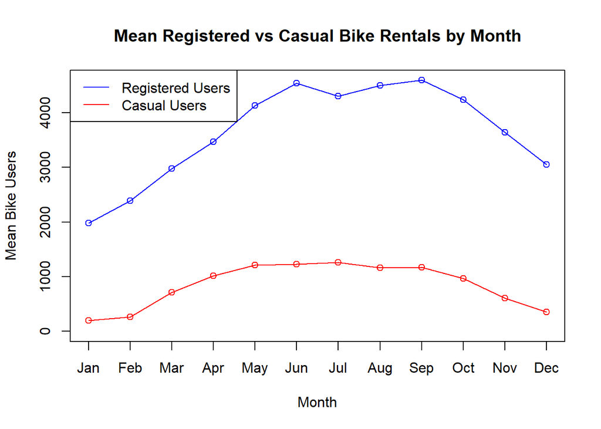

```r
# Calculate total registered users, by month
registered_data <- bike_share %>%
  group_by(month) %>%
  summarise(total_registered = mean(registered))

# Calculate total casual users, by month
casual_data <- bike_share %>%
  group_by(month) %>%
  summarise(total_casual = mean(casual))

# Find the maximum value of users for the range of the graph
max_value <- max(max(registered_data$total_registered), max(casual_data$total_casual))

# Plot for mean registered users by month
plot(registered_data$month, registered_data$total_registered,
     type = "o", col = "blue",
     xlab = "Month", ylab = "Mean Bike Users",
     main = "Mean Registered vs Casual Bike Rentals by Month",
     ylim = c(0, max_value),
     xaxt = "n")

# Plot for mean casual users by month
lines(casual_data$month, casual_data$total_casual,
      type = "o", col = "red")

# Set x labels
axis(1, at = registered_data$month, labels = c("Jan", "Feb", "Mar", "Apr",
                                               "May", "Jun", "Jul", "Aug",
                                               "Sep", "Oct", "Nov", "Dec"))

# Add legends to identify the two graphs
legend("topleft", legend = c("Registered Users", "Casual Users"),
       col = c("blue", "red"), lty = 1)
```

### Violin Plot: The distribution of users by season

In addition, we think that a violin plot with a box plot in the middle would be an excellent way to show the distribution of registered users per season while also showing the interquartile ranges and the median. The frequency of the registered and casual users show where the count for registered and count were the most repeated per day. So the median and interquartile ranges would reflect where the user count remained for the most time over the two years: 2011 and 2012.[^4]

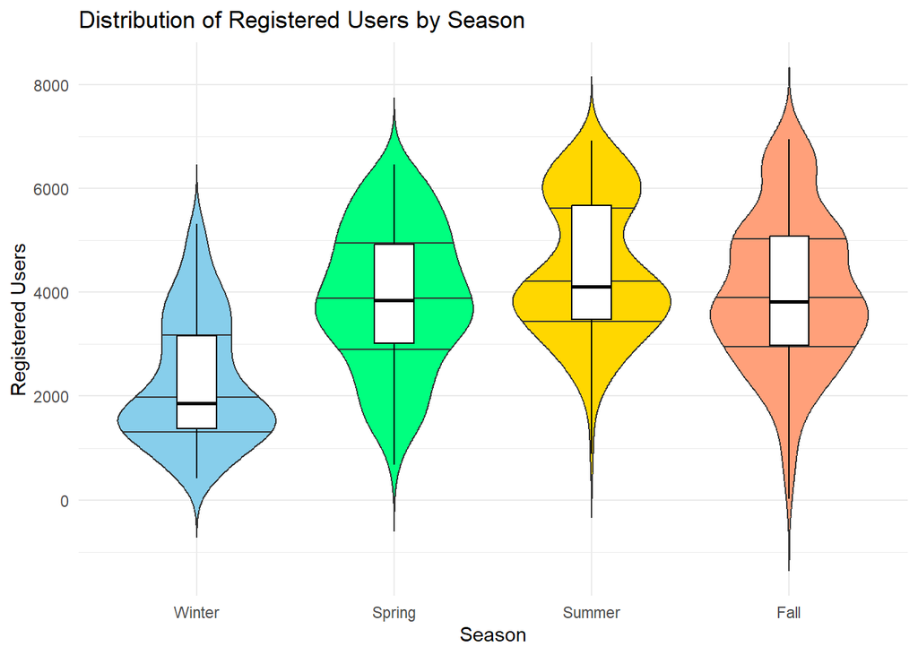

```r
# Create a longer dataframe that creates a column name user_type with values
# 'casual' and 'registered' users
bike_share_long <- bike_share %>%
  pivot_longer(cols = c("casual", "registered"), names_to = "user_type",
               values_to = "value")

# Plot the distribution of registered users, by season
bike_share %>%
  ggplot(aes(x = factor(season, levels = 1:4, labels = c("Winter", "Spring",
                                                         "Summer", "Fall")),
             y = registered,
             fill = factor(season, levels = 1:4, labels = c("Winter", "Spring",
                                                            "Summer", "Fall")))) +
  geom_violin(draw_quantiles = c(0.25, 0.5, 0.75), scale = "width", width = 0.8,
              trim = FALSE) +
  geom_boxplot(width = 0.2, fill = "white", color = "black", outlier.shape = NA) +
  scale_fill_manual(values = c("#87CEEB", "#00FF7F", "#FFD700", "#FFA07A")) +
  theme_minimal() +
  labs(x = "Season", y = "Registered Users") +
  ggtitle("Distribution of Registered Users by Season") +
  theme(legend.position = "none")
```

For registered users, we can see that the median user count per day for winter, spring, summer, and fall are 1867, 3844, 4110.5, and 3815 respectively. A greater interquartile range reflects more changes in the user count within the season.This is because the distribution reflects the frequency for a certain user count per day, so the more distributed this number, the more likely it is to vary. Thus, the interquartile range would be greater when variation is more expected. All the interquartile ranges seem to be about the same length, meaning that change is consistent within each season.

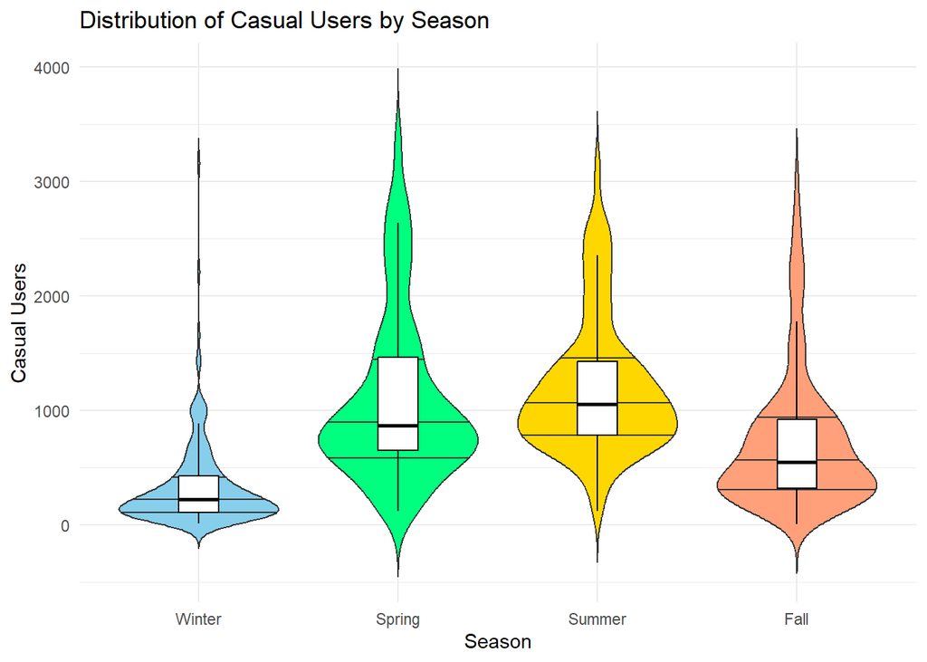

```r
# Plot the distribution of casual users, by season
bike_share %>%
  ggplot(aes(x = factor(season, labels = c("Winter", "Spring", "Summer", "Fall")),
             y = casual,
             fill = factor(season, labels = c("Winter", "Spring", "Summer",
                                              "Fall")))) +
  geom_violin(draw_quantiles = c(0.25, 0.5, 0.75), scale = "width", width = 0.8,
              trim = FALSE) +
  geom_boxplot(width = 0.2, fill = "white", color = "black", outlier.shape = NA) +
  scale_fill_manual(values = c("#87CEEB", "#00FF7F", "#FFD700", "#FFA07A")) +
  theme_minimal() +
  labs(x = "Season", y = "Casual Users") +
  ggtitle("Distribution of Casual Users by Season") +
  theme(legend.position = "none")
```

For casual users, we can see that the median user count per day for winter, spring, summer, and fall are 218, 867, 1050.5, and 544.5 respectively. This time, we can see that the interquartile ranges are smaller in casual, meaning that variations are less likely. Incorporating the curves of the violin plot, when the count occurs more, or is wider on the violin plot, it’s repeated more. This is because the wider locations on a violin plot reflect higher density. Because the seasons on this plot are wider near the median and thin out at the ends, this means that the casual user count frequents around the median. However, this is unlike the registered users because they maintain more density through each season.

### Box Plot: Registered vs. Casual Users by Holiday

Here we created a box plot to show the distribution of bike rentals during holidays and nonholidays. This compares the behavior of bike users based on whether the day was a holiday or not. The red boxplot shows the distribution of casual users whereas the blue boxplot represents the distribution of registered users.

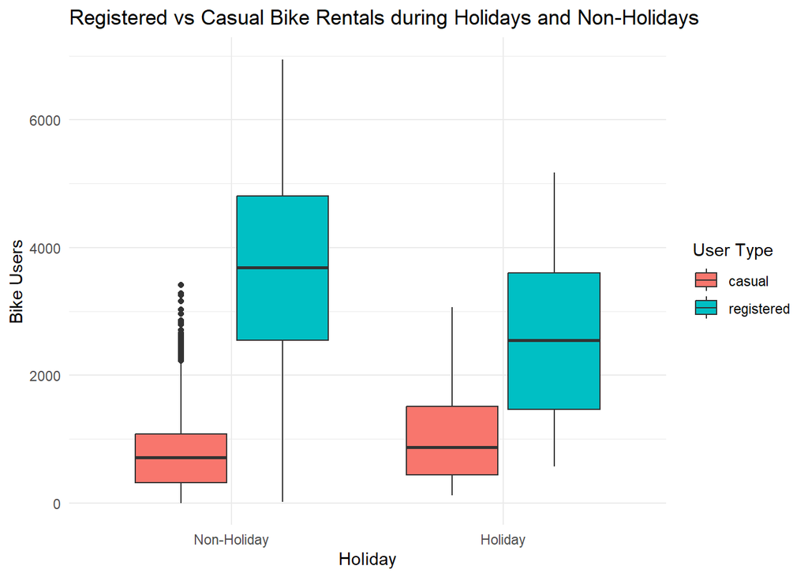

```r
# Create two boxplots, one for casual users and one for registered users, to
# show the distribution of bike rentals during holidays and non-holidays
ggplot(bike_share_long, aes(x = as.factor(holiday), y = value, fill = user_type)) +
  geom_boxplot() +
  labs(title = "Registered vs Casual Bike Rentals during Holidays and Non-Holidays",
       x = "Holiday",
       y = "Bike Users",
       fill = "User Type") +
  theme_minimal() +
  scale_x_discrete(labels = c("Non-Holiday", "Holiday"))
```

### Jitter Plot: Registered vs. Casual Bike Rentals by Weather

Lastly, we decided to do a jitter scatter plot to compare the user count where each dot represents a day and the count that day. The blue represents registered user count and the red represents casual user count.

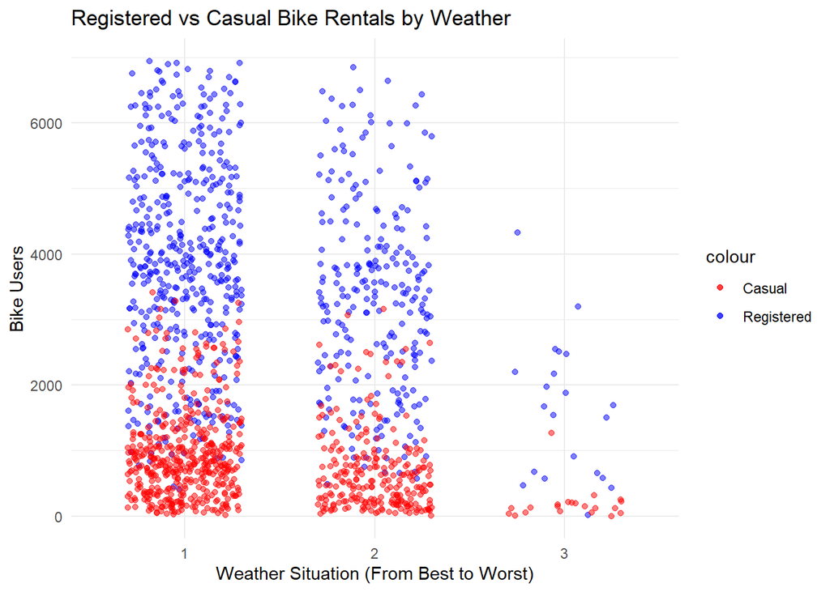

```r
# Create a jittered scatter plot by setting the `weather` variable to the x-axis
# and the y-variable as the number of bike users (both registered and casual
# users to compare)

ggplot(bike_share, aes(x = factor(weather),
                       y = registered, color = "Registered")) +
  geom_jitter(alpha = 0.5, width = 0.3) +
  geom_jitter(aes(y = casual, color = "Casual"), alpha = 0.5, width = 0.3) +
  scale_color_manual(values = c("Registered" = "blue", "Casual" = "red")) +
  labs(x = "Weather Situation (From Best to Worst)", y = "Bike Users",
       title = "Registered vs Casual Bike Rentals by Weather") +
  theme_minimal() +
  scale_x_discrete()
```

From the graph above, we can see that the weather (1 being “Clear, Few clouds, Partly cloudy, Partly cloudy”, 2 being “Mist + Cloudy, Mist + Broken clouds, Mist + Few clouds, Mist”, and 3 being “Light Snow + Light Rain + Thunderstorm + Scattered clouds, Light Rain + Scattered clouds”) shows that generally, there are more users on days where the weather is good. We can also see that a speculative transition line where the casual user count turns into registered user levels is lower when the weather is 2 instead of 1. (500 instead of 700 in count). There are not enough bad weather days (3) to make a conclusion about a transition line that describes the count where an observation is likely to be registered rather than casual.

## Discussion and Conclusion

This analysis is limited by the absence of statistical tests to determine if the differences between registered/casual user count or whether the changes in user count are actually real. However, the most severe impact is caused by the limited number of variables in the data set. There are so many more interesting factors to discover other than weather that could affect a bikeshare marketing campaign in Washington D.C., like economic conditions, political environment, tourism, technological advances, competitors, and even regulations. We also think that a larger data set would have helped since this data set only covers the course of two years, 2011 and 2012, and this information might even be outdated. Recent information would be even more ideal.